# CyclisticTripData

Tom C

2022-11-13

## R Markdown for Cyclistic Case Study

This is my first crack at creating a Rstudio and Rmarkdown case study.

I will start the Rmarkdown documentation at the point where my data is loaded and ready for data cleaning.

##Install and load packages

```r
library(dplyr)
library(tidyverse)  #helps wrangle data
library(lubridate)  #helps wrangle date attributes
```

```r
library(ggplot2)  #helps visualize data
library(readr)
```

## View the combined_trip_data

###View the dataset headers and find the variable type ###Inspect the new table that has been created

```r
combined_trip_data<-read_csv("combined_trip_data.csv")
```

```
## ──────────────────────────────────────────────────────── Delimiter: "," chr
## (7): ride_id, rideable_type, start_station_name, start_station_id, end_... dbl
## (6): ...1, start_lat, start_lng, end_lat, end_lng, day_of_week dttm (3):
## started_at, ended_at, ride_length
```

```r
head(combined_trip_data)
```

```
## # A tibble: 6 × 16
##    ...1 ride_id  ridea…¹ started_at          ended_at            start…² start…³
##   <dbl> <chr>    <chr>   <dttm>              <dttm>              <chr>   <chr>
## 1     1 C2F7DD7… electr… 2022-01-13 11:59:00 2022-01-13 12:02:00 Glenwo… 525
## 2     2 A6CF898… electr… 2022-01-10 08:41:00 2022-01-10 08:46:00 Glenwo… 525
## 3     3 BD0F91D… classi… 2022-01-25 04:53:00 2022-01-25 04:58:00 Sheffi… TA1306…
## 4     4 CBB80ED… classi… 2022-01-04 00:18:00 2022-01-04 00:33:00 Clark … KA1504…
## 5     5 DDC963B… classi… 2022-01-20 01:31:00 2022-01-20 01:37:00 Michig… TA1309…
## 6     6 A39C6F6… classi… 2022-01-11 18:48:00 2022-01-11 18:51:00 Wood S… 637
## # … with 9 more variables: end_station_name <chr>, end_station_id <chr>,
## #   start_lat <dbl>, start_lng <dbl>, end_lat <dbl>, end_lng <dbl>,
## #   member_casual <chr>, ride_length <dttm>, day_of_week <dbl>, and abbreviated
## #   variable names ¹rideable_type, ²start_station_name, ³start_station_id
```

```r
glimpse(combined_trip_data)
```

```
## Rows: 5,828,127
## Columns: 16
## $ ...1               <dbl> 1, 2, 3, 4, 5, 6, 7, 8, 9, 10, 11, 12, 13, 14, 15, …
## $ ride_id            <chr> "C2F7DD78E82EC875", "A6CF8980A652D272", "BD0F91DFF7…
## $ rideable_type      <chr> "electric_bike", "electric_bike", "classic_bike", "…
## $ started_at         <dttm> 2022-01-13 11:59:00, 2022-01-10 08:41:00, 2022-01-…
## $ ended_at           <dttm> 2022-01-13 12:02:00, 2022-01-10 08:46:00, 2022-01-…
## $ start_station_name <chr> "Glenwood Ave & Touhy Ave", "Glenwood Ave & Touhy A…
## $ start_station_id   <chr> "525", "525", "TA1306000016", "KA1504000151", "TA13…
## $ end_station_name   <chr> "Clark St & Touhy Ave", "Clark St & Touhy Ave", "Gr…
## $ end_station_id     <chr> "RP-007", "RP-007", "TA1307000001", "TA1309000021",…
## $ start_lat          <dbl> 42.01280, 42.01276, 41.92560, 41.98359, 41.87785, 4…
## $ start_lng          <dbl> -87.66591, -87.66597, -87.65371, -87.66915, -87.624…
## $ end_lat            <dbl> 42.01256, 42.01256, 41.92533, 41.96151, 41.88462, 4…
## $ end_lng            <dbl> -87.67437, -87.67437, -87.66580, -87.67139, -87.627…
## $ member_casual      <chr> "casual", "casual", "member", "casual", "member", "…
## $ ride_length        <dttm> 1899-12-31 00:02:57, 1899-12-31 00:04:21, 1899-12-…
## $ day_of_week        <dbl> 5, 2, 3, 3, 5, 3, 1, 7, 2, 6, 3, 7, 1, 5, 7, 6, 4, …
```

```r
colnames(combined_trip_data)  #List of column names
```

```
##  [1] "...1"               "ride_id"            "rideable_type"
##  [4] "started_at"         "ended_at"           "start_station_name"
##  [7] "start_station_id"   "end_station_name"   "end_station_id"
## [10] "start_lat"          "start_lng"          "end_lat"
## [13] "end_lng"            "member_casual"      "ride_length"
## [16] "day_of_week"
```

```r
nrow(combined_trip_data)  #How many rows are in data frame?
```

```
## [1] 5828127
```

```r
dim(combined_trip_data)  #Dimensions of the data frame?
```

```
## [1] 5828127      16
```

```r
head(combined_trip_data)  #See the first 6 rows of data frame.  Also tail(all_trips)
```

```
## # A tibble: 6 × 16
##    ...1 ride_id  ridea…¹ started_at          ended_at            start…² start…³
##   <dbl> <chr>    <chr>   <dttm>              <dttm>              <chr>   <chr>
## 1     1 C2F7DD7… electr… 2022-01-13 11:59:00 2022-01-13 12:02:00 Glenwo… 525
## 2     2 A6CF898… electr… 2022-01-10 08:41:00 2022-01-10 08:46:00 Glenwo… 525
## 3     3 BD0F91D… classi… 2022-01-25 04:53:00 2022-01-25 04:58:00 Sheffi… TA1306…
## 4     4 CBB80ED… classi… 2022-01-04 00:18:00 2022-01-04 00:33:00 Clark … KA1504…
## 5     5 DDC963B… classi… 2022-01-20 01:31:00 2022-01-20 01:37:00 Michig… TA1309…
## 6     6 A39C6F6… classi… 2022-01-11 18:48:00 2022-01-11 18:51:00 Wood S… 637
## # … with 9 more variables: end_station_name <chr>, end_station_id <chr>,
## #   start_lat <dbl>, start_lng <dbl>, end_lat <dbl>, end_lng <dbl>,
## #   member_casual <chr>, ride_length <dttm>, day_of_week <dbl>, and abbreviated
## #   variable names ¹rideable_type, ²start_station_name, ³start_station_id
```

```r
str(combined_trip_data)  #See list of columns and data types (numeric, character, etc)
```

```
## spec_tbl_df [5,828,127 × 16] (S3: spec_tbl_df/tbl_df/tbl/data.frame)
##  $ ...1              : num [1:5828127] 1 2 3 4 5 6 7 8 9 10 ...
##  $ ride_id           : chr [1:5828127] "C2F7DD78E82EC875" "A6CF8980A652D272" "BD0F91DFF741C66D" "CBB80ED419105406" ...
##  $ rideable_type     : chr [1:5828127] "electric_bike" "electric_bike" "classic_bike" "classic_bike" ...
##  $ started_at        : POSIXct[1:5828127], format: "2022-01-13 11:59:00" "2022-01-10 08:41:00" ...
##  $ ended_at          : POSIXct[1:5828127], format: "2022-01-13 12:02:00" "2022-01-10 08:46:00" ...
##  $ start_station_name: chr [1:5828127] "Glenwood Ave & Touhy Ave" "Glenwood Ave & Touhy Ave" "Sheffield Ave & Fullerton Ave" "Clark St & Bryn Mawr Ave" ...
##  $ start_station_id  : chr [1:5828127] "525" "525" "TA1306000016" "KA1504000151" ...
##  $ end_station_name  : chr [1:5828127] "Clark St & Touhy Ave" "Clark St & Touhy Ave" "Greenview Ave & Fullerton Ave" "Paulina St & Montrose Ave" ...
##  $ end_station_id    : chr [1:5828127] "RP-007" "RP-007" "TA1307000001" "TA1309000021" ...
##  $ start_lat         : num [1:5828127] 42 42 41.9 42 41.9 ...
##  $ start_lng         : num [1:5828127] -87.7 -87.7 -87.7 -87.7 -87.6 ...
##  $ end_lat           : num [1:5828127] 42 42 41.9 42 41.9 ...
##  $ end_lng           : num [1:5828127] -87.7 -87.7 -87.7 -87.7 -87.6 ...
##  $ member_casual     : chr [1:5828127] "casual" "casual" "member" "casual" ...
##  $ ride_length       : POSIXct[1:5828127], format: "1899-12-31 00:02:57" "1899-12-31 00:04:21" ...
##  $ day_of_week       : num [1:5828127] 5 2 3 3 5 3 1 7 2 6 ...
##  - attr(*, "spec")=
##   .. cols(
##   ..   ...1 = col_double(),
##   ..   ride_id = col_character(),
##   ..   rideable_type = col_character(),
##   ..   started_at = col_datetime(format = ""),
##   ..   ended_at = col_datetime(format = ""),
##   ..   start_station_name = col_character(),
##   ..   start_station_id = col_character(),
##   ..   end_station_name = col_character(),
##   ..   end_station_id = col_character(),
##   ..   start_lat = col_double(),
##   ..   start_lng = col_double(),
##   ..   end_lat = col_double(),
##   ..   end_lng = col_double(),
##   ..   member_casual = col_character(),
##   ..   ride_length = col_datetime(format = ""),
##   ..   day_of_week = col_double()
##   .. )
##  - attr(*, "problems")=<externalptr>
```

```r
summary(combined_trip_data)  #Statistical summary of data. Mainly for numerics
```

```
##       ...1           ride_id          rideable_type
##  Min.   :      1   Length:5828127     Length:5828127
##  1st Qu.:1457032   Class :character   Class :character
##  Median :2914064   Mode  :character   Mode  :character
##  Mean   :2914064
##  3rd Qu.:4371096
##  Max.   :5828127
##
##    started_at                        ended_at
##  Min.   :2021-10-01 00:00:00.00   Min.   :2021-10-01 00:03:00.00
##  1st Qu.:2022-02-28 19:24:00.00   1st Qu.:2022-02-28 19:37:00.00
##  Median :2022-06-08 06:42:00.00   Median :2022-06-08 06:55:00.00
##  Mean   :2022-05-06 21:40:06.84   Mean   :2022-05-06 21:59:43.15
##  3rd Qu.:2022-08-02 11:26:00.00   3rd Qu.:2022-08-02 11:46:00.00
##  Max.   :2022-09-30 23:59:00.00   Max.   :2022-10-05 19:53:00.00
##
##  start_station_name start_station_id   end_station_name   end_station_id
##  Length:5828127     Length:5828127     Length:5828127     Length:5828127
##  Class :character   Class :character   Class :character   Class :character
##  Mode  :character   Mode  :character   Mode  :character   Mode  :character
##
##
##
##
##    start_lat       start_lng         end_lat         end_lng
##  Min.   :41.64   Min.   :-87.84   Min.   :41.39   Min.   :-88.97
##  1st Qu.:41.88   1st Qu.:-87.66   1st Qu.:41.88   1st Qu.:-87.66
##  Median :41.90   Median :-87.64   Median :41.90   Median :-87.64
##  Mean   :41.90   Mean   :-87.65   Mean   :41.90   Mean   :-87.65
##  3rd Qu.:41.93   3rd Qu.:-87.63   3rd Qu.:41.93   3rd Qu.:-87.63
##  Max.   :45.64   Max.   :-73.80   Max.   :42.37   Max.   :-87.30
##                                   NA's   :5844    NA's   :5844
##  member_casual       ride_length                      day_of_week
##  Length:5828127     Min.   :1899-12-31 00:00:00.00   Min.   :1.000
##  Class :character   1st Qu.:1899-12-31 00:05:56.00   1st Qu.:2.000
##  Mode  :character   Median :1899-12-31 00:10:29.00   Median :4.000
##                     Mean   :1899-12-31 00:17:06.96   Mean   :4.117
##                     3rd Qu.:1899-12-31 00:18:51.00   3rd Qu.:6.000
##                     Max.   :1900-01-28 06:25:01.00   Max.   :7.000
##
```

##Add columns that split out the dates so we can do more analysis

```r
combined_trip_data$date <- as.Date(combined_trip_data$started_at)
combined_trip_data$month <- format(as.Date(combined_trip_data$date), "%m")
combined_trip_data$day <- format(as.Date(combined_trip_data$date), "%d")
combined_trip_data$year <- format(as.Date(combined_trip_data$date), "%Y")
combined_trip_data$day_of_week <- format(as.Date(combined_trip_data$date), "%A")
```

##Calculating the ride length and making it numeric so we can do calcs

```r
combined_trip_data$ride_length <- difftime(combined_trip_data$ended_at,combined_trip_data$started_at)
str(combined_trip_data$ride_length)
```

```
##  'difftime' num [1:5828127] 180 300 300 900 ...
##  - attr(*, "units")= chr "secs"
```

```r
combined_trip_data$ride_length <- as.numeric(as.character(combined_trip_data$ride_length))
is.numeric(combined_trip_data$ride_length)
```

```
## [1] TRUE
```

```r
str(combined_trip_data$ride_length)
```

```
##  num [1:5828127] 180 300 300 900 360 180 1020 720 1560 480 ...
```

##remove instances where ride length was negative due to service being performed and create a new copy of the data.

```r
new_combined <- combined_trip_data[!(combined_trip_data$start_station_name == "HQ QR" | combined_trip_data$ride_length<0),]
```

##Saving the data

```r
save(new_combined,file="new_combined.RData")
```

##removing NA from the dataset and saving as new_combined2

```r
new_combined2<-na.omit(new_combined)
save(new_combined2,file="new_combined2.RData")
```

##Looking at key parts of the data-could use summary() but decided manually ##reviewing would be better practice.

```r
mean(new_combined2$ride_length)
```

```
## [1] 1058.709
```

```r
median(new_combined2$ride_length)
```

```
## [1] 660
```

```r
max(new_combined2$ride_length)
```

```
## [1] 2442300
```

```r
min(new_combined2$ride_length)
```

```
## [1] 0
```

##start comparing members with casual users using aggregate function

```r
aggregate(new_combined2$ride_length~new_combined2$member_casual,FUN=mean)
```

```
##   new_combined2$member_casual new_combined2$ride_length
## 1                      casual                 1513.5905
## 2                      member                  750.0527
```

```r
aggregate(new_combined2$ride_length~new_combined2$member_casual,FUN=median)
```

```
##   new_combined2$member_casual new_combined2$ride_length
## 1                      casual                       840
## 2                      member                       540
```

```r
aggregate(new_combined2$ride_length~new_combined2$member_casual,FUN=max)
```

```
##   new_combined2$member_casual new_combined2$ride_length
## 1                      casual                   2442300
## 2                      member                     89580
```

```r
aggregate(new_combined2$ride_length~new_combined2$member_casual,FUN=min)
```

```
##   new_combined2$member_casual new_combined2$ride_length
## 1                      casual                         0
## 2                      member                         0
```

##Average ride time for each day of the week

```r
aggregate(new_combined2$ride_length~new_combined2$member_casual+new_combined2$day_of_week,FUN=mean)
```

```
##    new_combined2$member_casual new_combined2$day_of_week
## 1                       casual                    Friday
## 2                       member                    Friday
## 3                       casual                    Monday
## 4                       member                    Monday
## 5                       casual                  Saturday
## 6                       member                  Saturday
## 7                       casual                    Sunday
## 8                       member                    Sunday
## 9                       casual                  Thursday
## 10                      member                  Thursday
## 11                      casual                   Tuesday
## 12                      member                   Tuesday
## 13                      casual                 Wednesday
## 14                      member                 Wednesday
##    new_combined2$ride_length
## 1                  1407.9755
## 2                   732.9656
## 3                  1560.7943
## 4                   724.4609
## 5                  1674.8122
## 6                   844.4023
## 7                  1725.2066
## 8                   838.1434
## 9                  1346.1494
## 10                  721.9386
## 11                 1348.4474
## 12                  709.8263
## 13                 1307.0318
## 14                  713.4251
```

##reorder the days of the week

```r
new_combined2$day_of_week<-ordered(new_combined2$day_of_week,levels=c("Sunday","Monday", "Tuesday", "Wednesday", "Thursday", "Friday", "Saturday"))
aggregate(new_combined2$ride_length~new_combined2$member_casual+new_combined2$day_of_week,FUN=mean)
```

```
##    new_combined2$member_casual new_combined2$day_of_week
## 1                       casual                    Sunday
## 2                       member                    Sunday
## 3                       casual                    Monday
## 4                       member                    Monday
## 5                       casual                   Tuesday
## 6                       member                   Tuesday
## 7                       casual                 Wednesday
## 8                       member                 Wednesday
## 9                       casual                  Thursday
## 10                      member                  Thursday
## 11                      casual                    Friday
## 12                      member                    Friday
## 13                      casual                  Saturday
## 14                      member                  Saturday
##    new_combined2$ride_length
## 1                  1725.2066
## 2                   838.1434
## 3                  1560.7943
## 4                   724.4609
## 5                  1348.4474
## 6                   709.8263
## 7                  1307.0318
## 8                   713.4251
## 9                  1346.1494
## 10                  721.9386
## 11                 1407.9755
## 12                  732.9656
## 13                 1674.8122
## 14                  844.4023
```

##average ride time for casual and member each day

```r
aggregate(new_combined2$ride_length~new_combined2$member_casual+new_combined2$day_of_week,FUN=mean)
```

```
##    new_combined2$member_casual new_combined2$day_of_week
## 1                       casual                    Sunday
## 2                       member                    Sunday
## 3                       casual                    Monday
## 4                       member                    Monday
## 5                       casual                   Tuesday
## 6                       member                   Tuesday
## 7                       casual                 Wednesday
## 8                       member                 Wednesday
## 9                       casual                  Thursday
## 10                      member                  Thursday
## 11                      casual                    Friday
## 12                      member                    Friday
## 13                      casual                  Saturday
## 14                      member                  Saturday
##    new_combined2$ride_length
## 1                  1725.2066
## 2                   838.1434
## 3                  1560.7943
## 4                   724.4609
## 5                  1348.4474
## 6                   709.8263
## 7                  1307.0318
## 8                   713.4251
## 9                  1346.1494
## 10                  721.9386
## 11                 1407.9755
## 12                  732.9656
## 13                 1674.8122
## 14                  844.4023
```

##counting number of rides by membe and casual and day

```r
new_combined2%>%
  mutate(weekday=wday(started_at,label=TRUE))%>%
  group_by(member_casual,weekday)%>%
  summarise(number_of_rides=n()
  ,average_duration=mean(ride_length))%>%
  arrange(member_casual,weekday)
```

```
## # A tibble: 14 × 4
## # Groups:   member_casual [2]
##    member_casual weekday number_of_rides average_duration
##    <chr>         <ord>             <int>            <dbl>
##  1 casual        Sun              299854            1725.
##  2 casual        Mon              197916            1561.
##  3 casual        Tue              191385            1348.
##  4 casual        Wed              193215            1307.
##  5 casual        Thu              207015            1346.
##  6 casual        Fri              238158            1408.
##  7 casual        Sat              363076            1675.
##  8 member        Sun              287455             838.
##  9 member        Mon              352109             724.
## 10 member        Tue              402719             710.
## 11 member        Wed              396173             713.
## 12 member        Thu              378676             722.
## 13 member        Fri              346249             733.
## 14 member        Sat              328167             844.
```

##visualization for number of rides

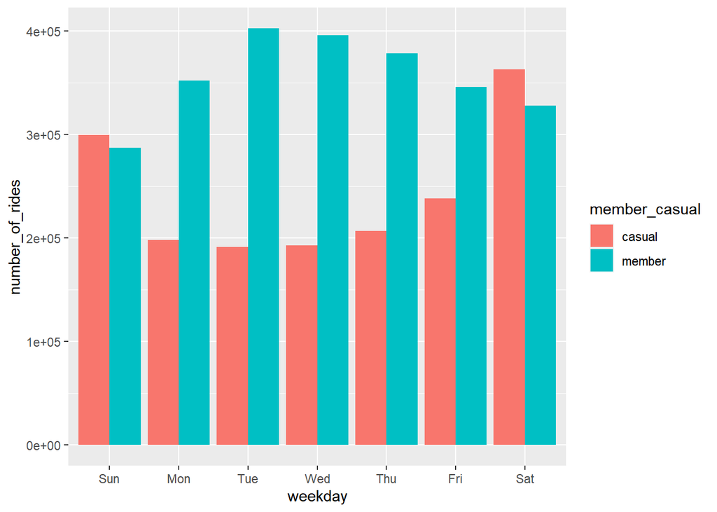

```r
new_combined2 %>%
  mutate(weekday = wday(started_at, label = TRUE)) %>%
  group_by(member_casual, weekday) %>%
  summarise(number_of_rides = n()
            ,average_duration = mean(ride_length)) %>%
  arrange(member_casual, weekday)  %>%
  ggplot(aes(x = weekday, y = number_of_rides, fill = member_casual)) +
  geom_col(position = "dodge")
```

```r
  ggsave("number_of_rides_plot.png")
```

##visualization for average duration

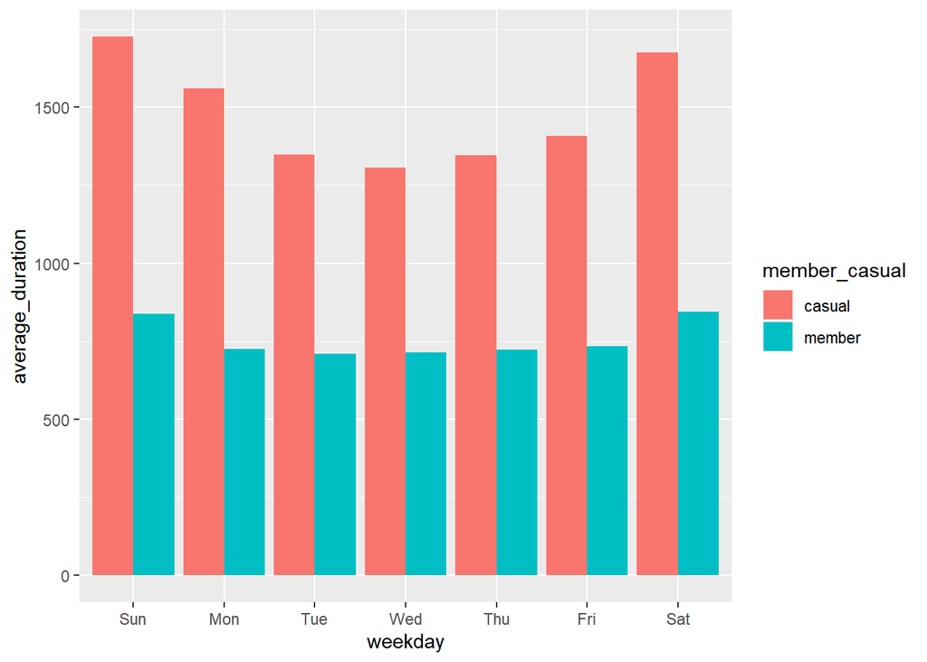

```r
new_combined2 %>%
  mutate(weekday = wday(started_at, label = TRUE)) %>%
  group_by(member_casual, weekday) %>%
  summarise(number_of_rides = n()
            ,average_duration = mean(ride_length)) %>%
  arrange(member_casual, weekday)  %>%
  ggplot(aes(x = weekday, y = average_duration, fill = member_casual)) +
  geom_col(position = "dodge")
```

```r
  ggsave("number_of_rides_plot.png")
```

##export for use in tableau or other software-saving my csv file

```r
counts <- aggregate(new_combined2$ride_length ~ new_combined2$member_casual + new_combined2$day_of_week, FUN = mean)
write.csv(counts, file = 'C:/Users/ltcas/Documents/Data Analytics/2021_2022_Trip_Data/trip_data-file/avg_ride_length.csv')
```